# Informe 1

Jhonatan Castañeda

7 de octubre de 2015

# 1.-

# Introducción

El presente documento tiene como objetivo presentar un **reporte** automático utilizando:

- R
- Markdown
  - **Rmarkdown**

# Descripción e información

Iniciamos cargando el archivo que contiene las variables a utilizar, el paquete *readxl* permite leer archivos desde excel, que es donde suelen estar los archivos, sin la necesidad de instalar complementos, pero en este caso usaremos el paquete *haven* pues la data está en formato spss.

```r
options(warn=-1)
library(haven)
library(dplyr)
library(DT)
library(sqldf)
library(readxl)
poblacion <- read_excel("poblacion.xlsx", sheet = 1)
poblacion <- subset(poblacion,poblacion[2]=="ESMERALDAS")
pob_1 <- substring(poblacion[[1]],1,2)
pob_1 <- as.numeric(pob_1)
pob_2 <- substring(poblacion[[1]],3,4)
pob_2 <- as.numeric(pob_2)
pob_3 <- substring(poblacion[[1]],5,6)
pob_3 <- as.numeric(pob_3)
poblacion <- cbind(poblacion,pob_1,pob_2,pob_3)
data <- read_sav("SPSS_Esmeraldas_Poblacion.sav")
data$I02 <- as.numeric(data$I02)
data$P01 <- as.numeric(data$P01)
cod <- names(data)[1:13]
variables_ <- c("PROVINCIA","CANTON","PARROQUIA","ZONA","SECTOR","VIVIENDA","HOGAR","URB_RUR","ORDEN EN EL HOGAR","C Y D EN ESE HOGAR","SEXO","PARENTESCO CON JEFE DE HOGAR","EDAD")
TABLA_ <- data.frame(cod,variables_)
datatable(TABLA_)
```

|  | cod | variables_ |
| --- | --- | --- |
| 1 | I01 | PROVINCIA |
| 2 | I02 | CANTON |
| 3 | I03 | PARROQUIA |
| 4 | I04 | ZONA |
| 5 | I05 | SECTOR |
| 6 | I09 | VIVIENDA |
| 7 | I10 | HOGAR |
| 8 | URP | URB_RUR |
| 9 | P00 | ORDEN EN EL HOGAR |
| 10 | PCD | C Y D EN ESE HOGAR |

[output cut: 3 more lines]

```r
POB__1 <-sqldf("SELECT I02
      FROM data
      GROUP BY I02")
POB__2 <-sqldf("SELECT I03
      FROM data
      GROUP BY I03")

# glimpse(data) mostraria información técnica de la data
```

Analizando la información disponemos de 534092 observaciones de 100 variables. Se requiere explicar la mayor cantidad de variables, en este caso se analizaran las primeras 13 variables por lo que en la tabla se muestran solo estas, ya que son las que mayor información nos dan sobre los datos, se debe tomar en cuenta las siguientes cuestiones:

## Los Códigos usados para la variable CANTON significan:

```r
clo__1 <- c(1:length(POB__1[[1]]))
for (i in 1:length(POB__1[[1]])){
  for(j in 1:length(poblacion[[1]])){
clo__1[i]<-ifelse(poblacion[[7]][j]==POB__1[[1]][i],poblacion[[3]][j],clo__1[i])
  }
}
TABLA_ <- cbind(POB__1[[1]],clo__1)
datatable(TABLA_)
```

| V1 | clo__1 |
| --- | --- |
| 1 | ESMERALDAS |
| 2 | ELOY ALFARO |
| 3 | MUISNE |
| 4 | QUININDE |
| 5 | SAN LORENZO |
| 6 | ATACAMES |
| 7 | RIOVERDE |
| 8 | LA CONCORDIA |

## Los Códigos usados para la variable PARROQUIA significan:

```r
clo__2 <- c(1:length(POB__2[[1]]))
for (i in 1:length(POB__2[[1]])){
  for(j in 1:length(poblacion[[1]])){
clo__2[i]<-ifelse(poblacion[[8]][j]==POB__2[[1]][i],poblacion[[4]][j],clo__2[i])
  }
}
TABLA_ <- cbind(POB__2[[1]],clo__2)
datatable(TABLA_)
```

| V1 | clo__2 |
| --- | --- |
| 50 | LA CONCORDIA |
| 51 | CHONTADURO |
| 52 | CHUMUNDE |
| 53 | LAGARTO |
| 54 | MONTALVO |
| 55 | ROCAFUERTE |
| 56 | CONCEPCION |
| 57 | MATAJE |
| 58 | SAN JAVIER DE CACHAVI |
| 59 | SANTA RITA |

[output cut: 8 more lines]

## Iniciaremos por ver las variables:

### Empleamos el paquete `sqldf()`para poder usar lo siguiente:

En lo siguiente veremos los diferentes valores que toma cada variable, la cantidad de veces que aparece en los datos cada uno de estos valores, es decir la cantidad de personas que se tienen registradas en cada uno de los valores de las variables, la edad máxima y mínima.

### Cantidad de personas registradas en cada CANTON:

```r
sqldf("SELECT I02, count(I03) AS POBL,max(P03) AS EDAD_MAX,min(P03) AS EDAD_MIN
      FROM data
      Group By I02")
```

```
##   I02   POBL EDAD_MAX EDAD_MIN
## 1   1 189504      114        0
## 2   2  39739      111        0
## 3   3  28474      107        0
## 4   4 122570      120        0
## 5   5  42486      115        0
## 6   6  41526      115        0
## 7   7  26869      111        0
## 8   8  42924      110        0
```

### Cantidad de personas registradas en cada PARROQUIA:

```r
sqldf("SELECT I03, count(I04) AS POBL,max(P03) AS EDAD_MAX,min(P03) AS EDAD_MIN
      FROM data
      Group By I03")
```

```
##    I03   POBL EDAD_MAX EDAD_MIN
## 1   50 334072      115        0
## 2   51  18799      103        0
## 3   52  19932      104        0
## 4   53  43858      110        0
## 5   54  31204      111        0
## 6   55  27297      120        0
## 7   56   7024      101        0
## 8   57   8508      100        0
## 9   58   6348      111        0
## 10  59   6107      102        0
## 11  60   2909      102        0
## 12  61   7934      111        0
## 13  62   2171      108        0
## 14  63   7252       99        0
## 15  64   1037      101        0
## 16  65   2660       98        0
## 17  66   3983      101        0
## 18  68   2997       94        0
```

### Cantidad de personas registradas en cada ZONA:

```r
sqldf("SELECT I04, count(I05) AS POBL,max(P03) AS EDAD_MAX,min(P03) AS EDAD_MIN
      FROM data
      Group By I04")
```

```
##    I04   POBL EDAD_MAX EDAD_MIN
## 1    1 100275      111        0
## 2    2  29945      120        0
## 3    3  24299      115        0
## 4    4  24012      110        0
## 5    5  17274      115        0
## 6    6  12031      100        0
## 7    7  13361      100        0
## 8    8   2650      104        0
## 9    9   3503       92        0
## 10  10   5704       96        0
## 11  11   4872      105        0
## 12  12   4142      107        0
## 13  13   6732       98        0
## 14  14   4065      111        0
```

[output cut: 46 more lines]

```r
sqldf("SELECT I05, count(I04) AS POBL,max(P03) AS EDAD_MAX,min(P03) AS EDAD_MIN
      FROM data
      Group By I04")
```

```
##    I05   POBL EDAD_MAX EDAD_MIN
## 1    1 100275      111        0
## 2    1  29945      120        0
## 3    1  24299      115        0
## 4    1  24012      110        0
## 5    1  17274      115        0
## 6    1  12031      100        0
## 7    1  13361      100        0
## 8    1   2650      104        0
## 9    1   3503       92        0
## 10   1   5704       96        0
## 11   1   4872      105        0
## 12   1   4142      107        0
## 13   1   6732       98        0
## 14   1   4065      111        0
```

[output cut: 46 more lines]

### Cantidad de personas registradas en cada EDAD:

```r
sqldf("SELECT P03, count(I05) AS POBL
      FROM data
      Group By P03")
```

```
##     P03  POBL
## 1     0 10931
## 2     1 13328
## 3     2 13442
## 4     3 13209
## 5     4 13588
## 6     5 12796
## 7     6 13633
## 8     7 13591
## 9     8 13939
## 10    9 13622
## 11   10 14957
## 12   11 13545
## 13   12 11439
## 14   13 12445
```

[output cut: 101 more lines]

# Gráficos:

Para la variable SEXO el Histograma que nos da información de la cantidad de datos receptados sobre cada uno de los valores que toma la variable es:

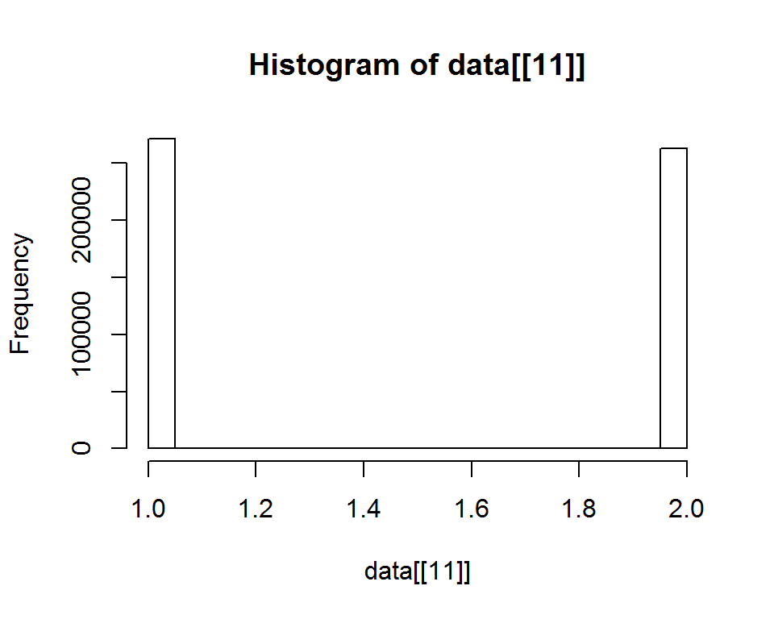

```r
hist(data[[11]],15)
```

Para la variable EDAD el Histograma que nos da información de la cantidad de datos receptados sobre cada uno de los valores que toma la variable es:

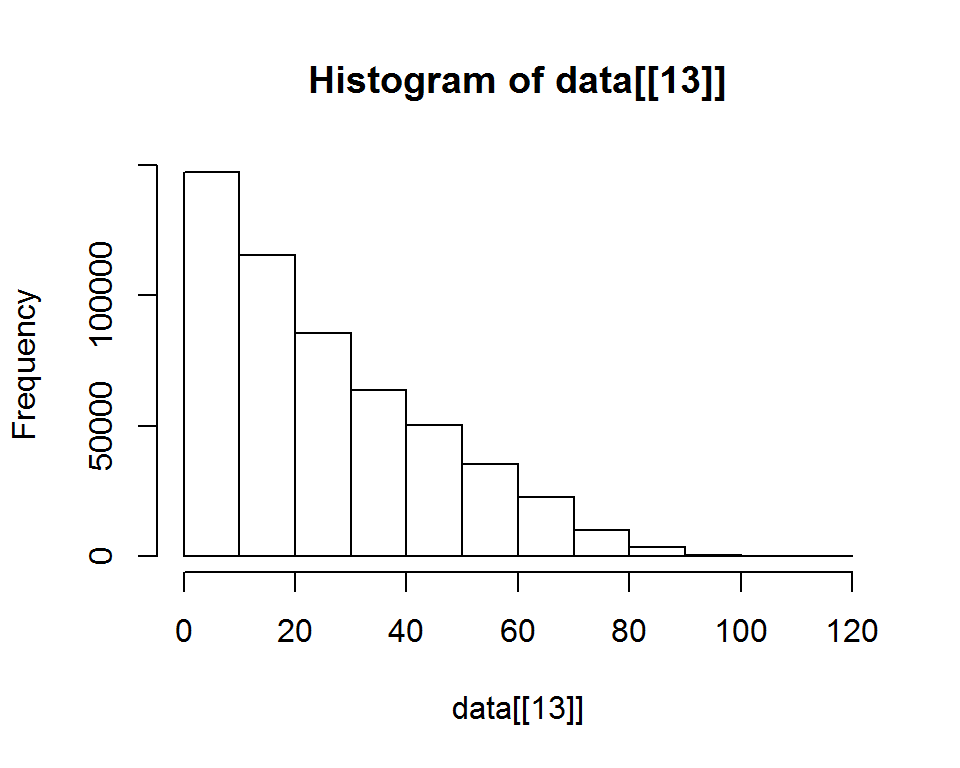

```r
hist(data[[13]],15)
```

El histograma nos da información como la de: la media que se encuentra en este caso en el valor de 25.788602 la mediana que se encuentra en este caso en el valor de 21,etc

El siguiente grafico muestra a EDAD vs CANTON, lo cual nos da informacion de como la EDAD de las personas se mueve en cada CANTON.

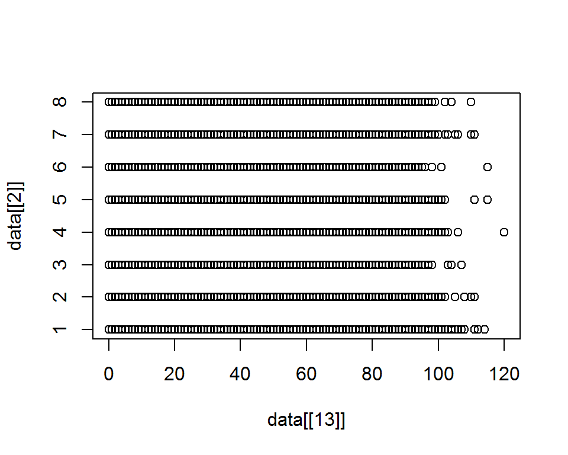

```r
plot(data[[13]],data[[2]])
```

El siguiente grafico muestra a EDAD vs PARROQUIA, lo cual nos da informacion de como la EDAD de las personas se mueve en cada PARROQUIA.

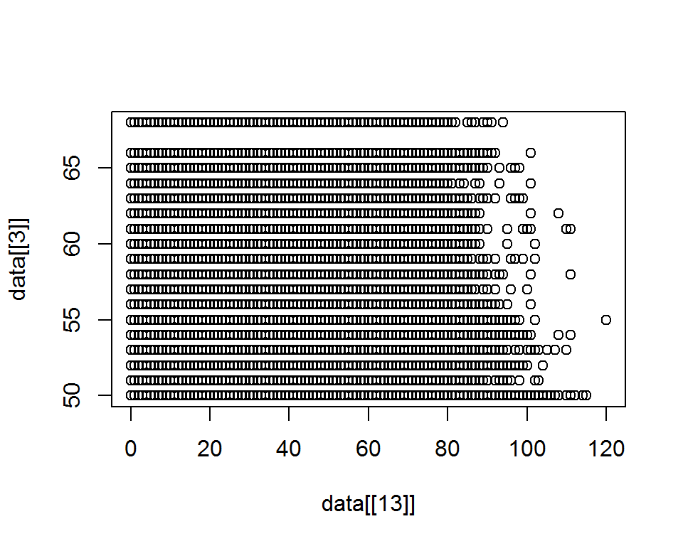

```r
plot(data[[13]],data[[3]])
```

El siguiente grafico muestra a EDAD vs ZONA, lo cual nos da informacion de como la EDAD de las personas se mueve en cada ZONA.

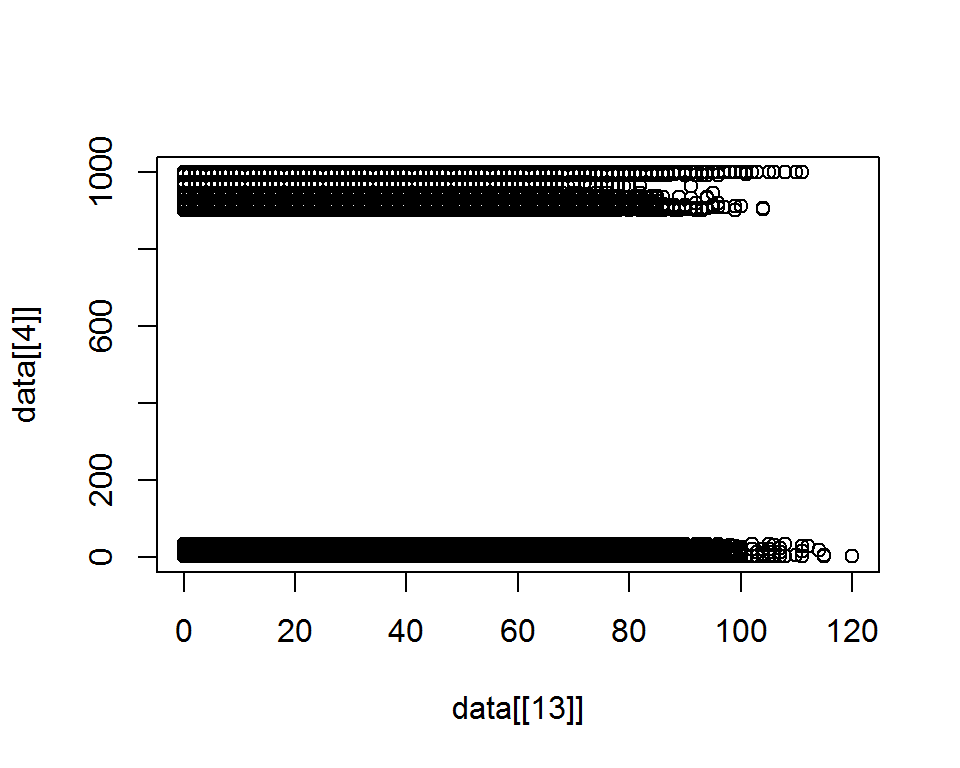

```r
plot(data[[13]],data[[4]])
```

El siguiente grafico muestra a EDAD vs SECTOR, lo cual nos da informacion de como la EDAD de las personas se mueve en cada SECTOR.

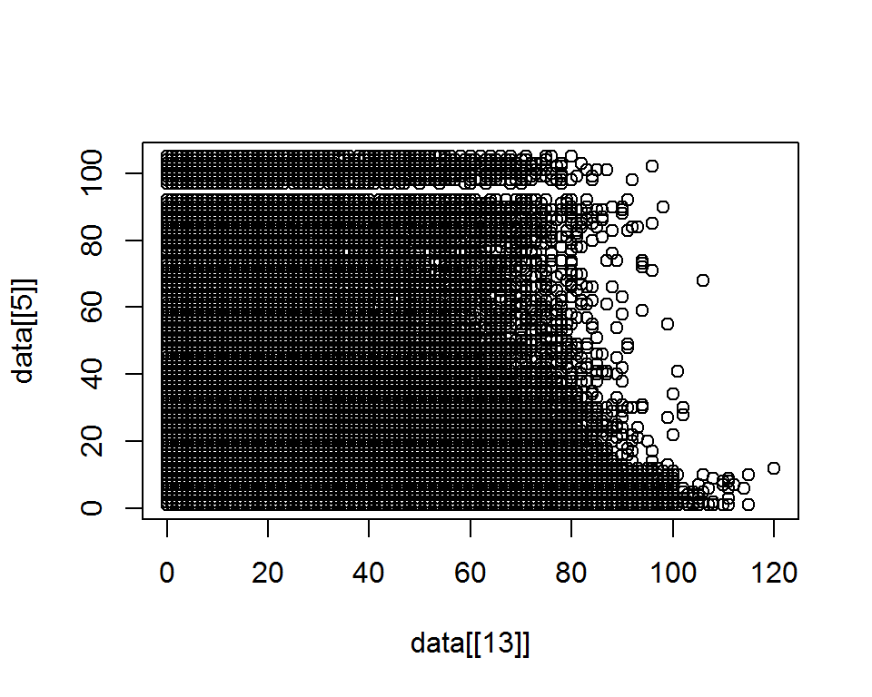

```r
plot(data[[13]],data[[5]])
```

El siguiente grafico muestra a EDAD vs SEXO, lo cual nos da informacion de como la EDAD de las personas se mueve en cada SEXO.

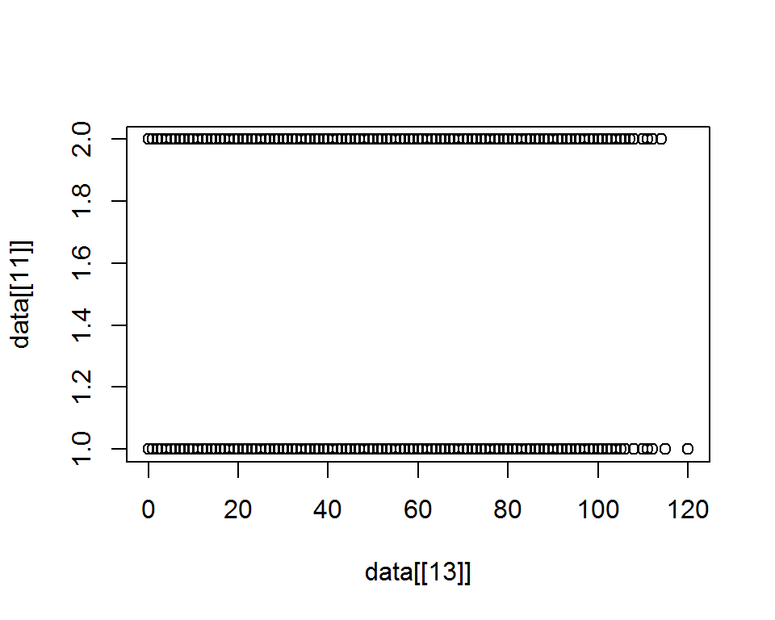

```r
plot(data[[13]],data[[11]])
```